# Homework 6

Sagar Jain

March 10, 2020

First, I download the dataset.

```r
library(gutenbergr)
books <- gutenberg_download(gutenberg_id = c(11, 1400),meta_fields = "title")
```

#### Part a)

##### *Question:*

Find the 10 most common non-stop-words in Great Expectations. Create a world cloud of them.

##### *Answer:*

First, I check how the titles are written. Then, I filter only *Great Expectations*, to only keep that part of the data.  
After that, I create the tibble to get a better structure.  
Next, I unnest the tokens to tidy the text.  
Then, I **anti_join** with the **stop words**, in order to avoid them in the counting.  
Finally, I do the **word cloud** to show the most used words.

```r
books %>% distinct(title)
```

```
## # A tibble: 2 x 1
##   title
##   <chr>
## 1 Alice's Adventures in Wonderland
## 2 Great Expectations
```

```r
great_expectations <- books %>%
  filter(title == 'Great Expectations')
great_expectations.tbl <-
  tibble(text = great_expectations$text) %>%
  mutate(linenumber = row_number(),
         chapter = cumsum(str_detect(text, "(?i)^chapter [0-9ivxlc]")))
tidy_great_expectations <- great_expectations.tbl %>%
  unnest_tokens(word, text)
tidy_great_expectations %>%
  anti_join(stop_words) %>%
  count(word, sort = TRUE) %>%
  head(10)
```

```
## # A tibble: 10 x 2
##    word         n
##    <chr>    <int>
##  1 joe        691
##  2 miss       383
##  3 time       373
##  4 pip        326
##  5 looked     325
##  6 herbert    290
##  7 hand       270
##  8 wemmick    256
##  9 havisham   243
## 10 estella    237
```

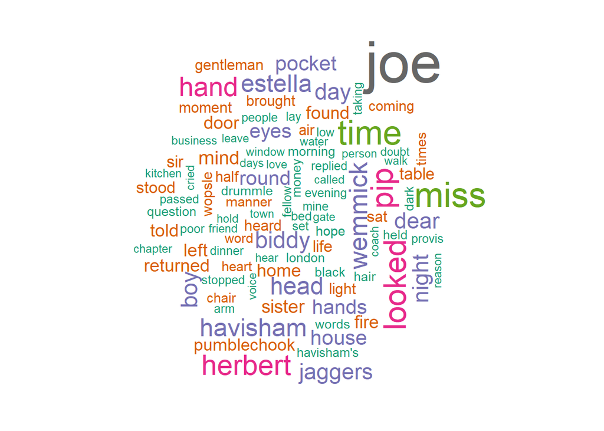

```r
tidy_great_expectations %>%
  anti_join(stop_words) %>%
  count(word) %>%
  with(wordcloud(word, n, max.words = 100, colors=brewer.pal(8, "Dark2")))
```

#### Part b)

##### *Question:*

Find the 10 most common bigrams in *Great Expectations* that do not include stop words.

##### *Answer:*

First, I get the bigrams in the text.  
Then, I separate the words into two columns.  
After, I filter those words, in both columns, that are in the stop words.  
Finally, I list the 10 most used bigrams.

```r
tidy_great_expectations_bigram <- great_expectations.tbl %>%
  unnest_tokens(bigram, text, token = "ngrams", n = 2)
great_expectations_bigrams_sep <- tidy_great_expectations_bigram %>%
  separate(bigram, c("word1", "word2"), sep = " ")
great_expectations_bigrams_filtered <- great_expectations_bigrams_sep %>%
  filter(!word1 %in% stop_words$word) %>%
  filter(!word2 %in% stop_words$word)
na.omit(great_expectations_bigrams_filtered %>%
  mutate(bigram = str_c(word1, ' ', word2)) %>%
  count(bigram, sort = TRUE)) %>%
  head(10)
```

```
## # A tibble: 10 x 2
##    bigram                n
##    <chr>             <int>
##  1 miss havisham       219
##  2 dear boy             70
##  3 miss havisham's      68
##  4 miss skiffins        25
##  5 jolly bargemen       19
##  6 trabb's boy          19
##  7 dear joe             18
##  8 sarah pocket         15
##  9 uncle pumblechook    15
## 10 barnard's inn        13
```

In this case I tidy both books first.  
Then, I join them with the sentiments list in the funcion **get_sentiments**.  
Finally, I plot the sentiments in both books.

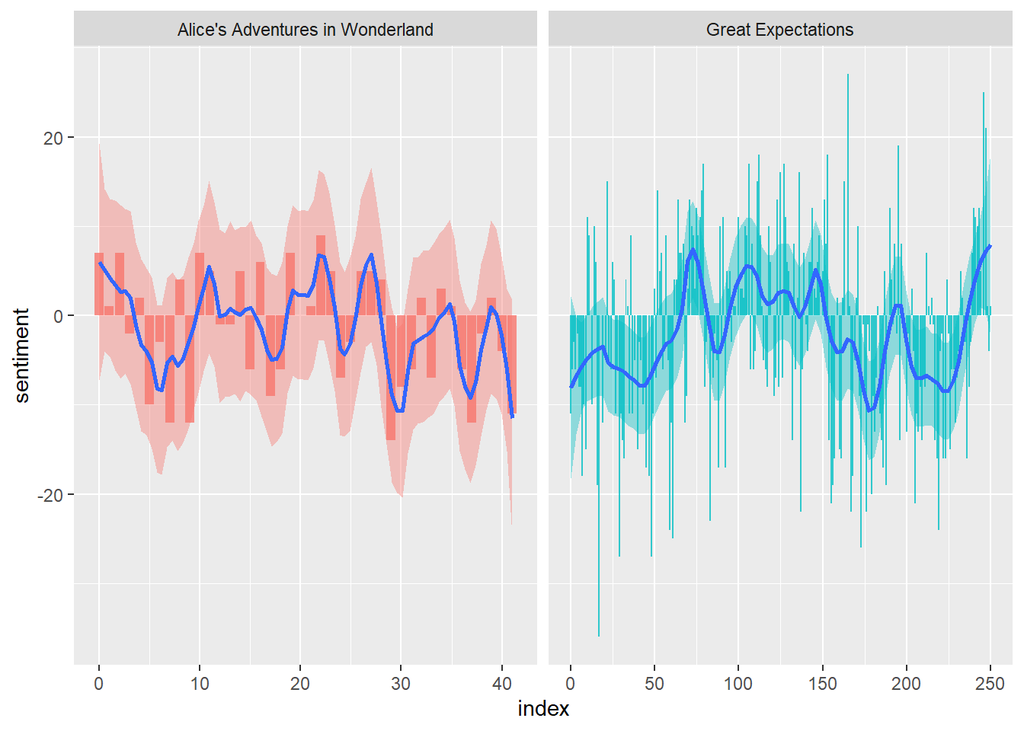

```r
tidy_books <- books %>%
  group_by(title) %>%
  mutate(linenumber = row_number(),
         chapter = cumsum(str_detect(text, regex("^chapter [\\divxlc]", ignore_case = TRUE)))) %>%
  ungroup()  %>%
  unnest_tokens(word, text)
books_sentiment <- tidy_books %>%
  inner_join(get_sentiments("bing")) %>%
  count(title, index = linenumber %/% 80, sentiment) %>%
  spread(sentiment, n, fill = 0) %>%
  mutate(sentiment = positive - negative)
ggplot(books_sentiment, aes(index, sentiment, fill = title)) +
  geom_bar(alpha = 0.8, stat = "identity", show.legend = FALSE) +
  facet_wrap(~title, ncol = 3, scales = "free_x") +
  theme(legend.position = "none") +
  geom_smooth(span = .15)
```

### Exercise 2

#### Part b)

##### *Question:*

I have choosen to implement *part b)*:

The weather forecast for next week from the closest (small) airport to Piscataway can be found at https://weather.com/weather/hourbyhour/l/USNJ0524:1:US. Download (and clean) the data using the code forecast <- “https://weather.com/weather/hourbyhour/l/USNJ0524:1:US” %>% read_html() %>% html_table(fill = TRUE) i. Create three separate plots (3  1 layout using facet_wrap()) of the time of day on the x-axis against temperature, humidity, and windspeed for the day on the y-axis (using points connected by lines for each), coloring the point by the chance of precipitation. Adjust the vertical scales accordingly.

First, I run the *cleaner functions*, and read the html from **www.weather.com**.  
After reading the html, I put it on a table in order to proceed.

```r
cleaner <- function(x){
  str_replace_all(x, " \\([0-9]+\\)|(\n)", "")
}
cleaner <- function(x){
  str_replace_all(x, "(^[ \t]+|[ \t]+$)|(\n)", "")
}
weather <- "https://weather.com/weather/hourbyhour/l/USNJ0524:1:US"
forecast <- weather %>%
  read_html() %>%
  html_table(fill = TRUE)
length(forecast)
```

```
## [1] 1
```

```r
class(forecast)
```

```
## [1] "list"
```

```r
class(forecast[[1]])
```

```
## [1] "data.frame"
```

```r
weather.df <- forecast[[1]]
weather.df %>%
  kable() %>%
  kable_styling()
```

| Time | Description | Temp | Feels | Precip | Humidity | Wind | NA |
| --- | --- | --- | --- | --- | --- | --- | --- |
| NA | 10:00 pmTue | Showers | 63° | 62° | 55% | 69% | W 9 mph |
| NA | 11:00 pmTue | Few Showers | 61° | 60° | 30% | 72% | WNW 9 mph |
| NA | 12:00 amWed | Cloudy | 59° | 57° | 15% | 72% | NW 9 mph |
| NA | 1:00 amWed | Mostly Cloudy | 57° | 55° | 15% | 72% | NNW 9 mph |
| NA | 2:00 amWed | Partly Cloudy | 52° | 49° | 0% | 72% | NNW 9 mph |
| NA | 3:00 amWed | Partly Cloudy | 49° | 46° | 0% | 70% | NNW 8 mph |
| NA | 4:00 amWed | Mostly Clear | 47° | 44° | 5% | 69% | NNW 6 mph |
| NA | 5:00 amWed | Clear | 46° | 43° | 5% | 69% | NNW 6 mph |
| NA | 6:00 amWed | Clear | 44° | 41° | 5% | 68% | NNW 5 mph |
| NA | 7:00 amWed | Clear | 42° | 39° | 5% | 69% | NNW 5 mph |
| NA | 8:00 amWed | Mostly Sunny | 42° | 38° | 5% | 67% | NNW 5 mph |
| NA | 9:00 amWed | Mostly Sunny | 44° | 40° | 0% | 59% | N 6 mph |
| NA | 10:00 amWed | Mostly Sunny | 47° | 43° | 0% | 51% | N 7 mph |
| NA | 11:00 amWed | Partly Cloudy | 50° | 47° | 0% | 43% | NNE 6 mph |
| NA | 12:00 pmWed | Mostly Cloudy | 52° | 51° | 0% | 38% | NNE 5 mph |
| NA | 1:00 pmWed | Mostly Cloudy | 54° | 53° | 0% | 34% | ENE 5 mph |

Looking at the columns, they are misplaced. Next, I have shifted the data under the correct variable name.

```r
# Drop the first column
weather.df <- weather.df[,-1]
length(weather.df)
```

```
## [1] 7
```

```r
names(weather.df)[7] <- "Wind_"
weather.df <- weather.df %>%
  rename(Time = Description) %>%
  rename(Description = Temp) %>%
  rename(Temp = Feels) %>%
  rename(Feels = Precip) %>%
  rename(Precip = Humidity) %>%
  rename(Humidity = Wind) %>%
  rename(Wind = Wind_)
```

After this correction, I began to tidy all the data.

```r
weather.df$Time <- weather.df$Time %>%
  str_replace_all("am", "am - ")  %>%
  str_replace_all("pm", "pm - ")
weather.df <- weather.df %>% separate(Time, c("Time", "Day"), sep = "-") %>% map_df(cleaner)
```

Fixing the time, precipitation and humidity percentage. In Precipitation case, I calculate it as a numerical value (from 0 to 1), so when using it on the plot, it keeps it in order. I put Humidity in a percentage format (0 to 100), so when using it on the plot is correctly represented.

```r
weather.clean <- weather.df %>%
  mutate(Time = parse_time(Time, '%I:%M %p')) %>%
  mutate(Precip = as.numeric(sub("%", "", Precip))/100) %>%
  mutate(Humidity = as.numeric(sub("%", "", Humidity)))
weather.clean$Temp <- weather.clean$Temp %>%
  str_replace_all("°", "") %>%
  as.numeric()
```

Next, because I am checking the data today, if the day is not the same as today’s, then it means that it corresponds to tomorrow. After that, I will correct the wind data.

```r
weather.clean1 <- weather.clean %>%
  filter(wday(today(tzone = "EST"), label=TRUE) == weather.clean$Day) %>%
  mutate("Datetime" = as_datetime(paste(today(tzone = "EST"), Time, sep= ' '), tz = "EST"))
weather.clean2 <- weather.clean %>%
  filter(wday(today(tzone = "EST"), label=TRUE) != weather.clean$Day) %>%
  mutate("Datetime" = as_datetime(paste(today(tzone = "EST") + 1, Time, sep= ' '), tz = "EST"))
weather.clean <- rbind(weather.clean1,weather.clean2)
weather.clean$Datetime <- format(weather.clean$Datetime,format='%Y-%m-%d %H:%M')
# Tidyng wind
weather.clean <- weather.clean %>% separate(Wind, c("Wind_Direction", "Wind_Speed", "Wind_measurement"), sep = " ") %>% map_df(cleaner)
weather.clean <- weather.clean %>% mutate(Wind_Speed = as.numeric(Wind_Speed))
head(weather.clean) %>%
  kable() %>%
  kable_styling()
```

| Time | Day | Description | Temp | Feels | Precip | Humidity | Wind_Direction | Wind_Speed | Wind_measurement | Datetime |
| --- | --- | --- | --- | --- | --- | --- | --- | --- | --- | --- |
| 22:00:00 | Tue | Showers | 63 | 62° | 0.55 | 69 | W | 9 | mph | 2020-03-10 22:00 |
| 23:00:00 | Tue | Few Showers | 61 | 60° | 0.3 | 72 | WNW | 9 | mph | 2020-03-10 23:00 |
| 00:00:00 | Wed | Cloudy | 59 | 57° | 0.15 | 72 | NW | 9 | mph | 2020-03-11 00:00 |
| 01:00:00 | Wed | Mostly Cloudy | 57 | 55° | 0.15 | 72 | NNW | 9 | mph | 2020-03-11 01:00 |
| 02:00:00 | Wed | Partly Cloudy | 52 | 49° | 0 | 72 | NNW | 9 | mph | 2020-03-11 02:00 |
| 03:00:00 | Wed | Partly Cloudy | 49 | 46° | 0 | 70 | NNW | 8 | mph | 2020-03-11 03:00 |

Now I have all the data tidy to answer the question.

##### *Answer:*

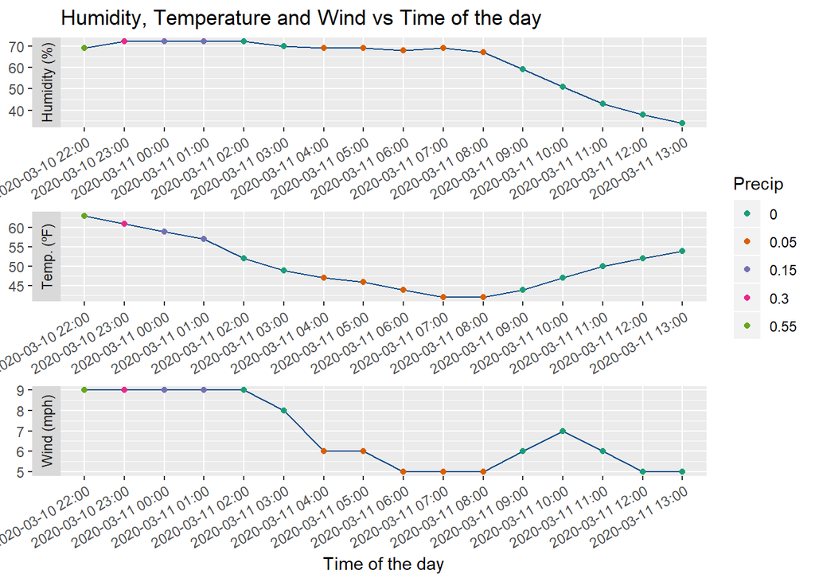

```r
weather.plot <- gather(weather.clean, key="measure", value="value", c("Temp",  "Humidity",  "Wind_Speed"))
weather.plot <- weather.plot %>%
  mutate(value = as.numeric(value))
ggplot(weather.plot, aes(Datetime, value, group = 1)) +
  geom_line(color = "dodgerblue4") + geom_point(aes(color=Precip)) +
  ggtitle("Humidity, Temperature and Wind vs Time of the day") +
  facet_wrap(~ measure, ncol = 1, scales = "free", strip.position = "left",
             labeller = labeller( measure = c(Temp = "Temp. (ºF)", Humidity = "Humidity (%)", "Wind_Speed" = "Wind (mph)"))) +
  ylab(NULL) +
  xlab("Time of the day") +
  theme(axis.text.x = element_text(angle = 30, hjust = 1)) +
  scale_color_brewer(palette = "Dark2")
```

### Exercise 3

Using the code from week6.R on Canvas, extract the rank, views, length, and post date of each video on Youtube’s trending page https://www.youtube.com/feed/trending. Call the rank rank and the number of views views.

First, download the data from **youtube.com**.  
After reading the html, I put it on a table in order to proceed.

```r
youtube <- "https://www.youtube.com/feed/trending" %>%
  read_html() %>% html_nodes("div") %>%
  html_text()
```

After downloading the data, I start to tidy it.

```r
youtube.clean <- youtube[2] %>% str_extract_all("(?!= Duration).*(?=views)") %>% unlist()
youtube.clean <- tibble(text = youtube.clean)
```

First, I separate the title from the rest of the string. Then, I take the minutes, seconds and views on separate steps.

```r
youtube.clean <- youtube.clean %>% separate(text, c("title", "rest"), sep = "- Duration: ") %>%
  subset(!is.na(rest)) %>%
  mutate(title = str_trim(title))
youtube.clean <- youtube.clean %>% separate(rest, c("minutes", "rest"), sep = ":")
youtube.clean <- youtube.clean %>% separate(rest, c("seconds", "rest"), sep = "\\.", extra = "merge")
youtube.clean <-  youtube.clean %>% separate(rest, c("rest", "views"), sep = " ago") %>%
   subset(!is.na(views))
youtube.clean$views <-
  youtube.clean$views %>%
  str_replace_all("[,]|[ ]", "") %>% as.numeric()
```

Now that I have eliminated those videos that do not correspond to the ranking, I create a variable **rank**, assigning a ranking number to each video.  
Then, I take the time unit from the rest of the original string, and I erased it from it.  
Finally, I create a new variable that has the numeric value of how long has the video was posted.

```r
youtube.clean <-  youtube.clean %>%
  mutate(rank = 1:dim(youtube.clean)[1])
youtube.clean$time_unit <- word(youtube.clean$rest, -1)
youtube.clean$rest <-
  youtube.clean$rest %>%
  str_replace_all("(day)s?", "") %>%
  str_replace_all("(week)s?", "") %>%
  str_replace_all("(hour)s?", "")
youtube.clean <- youtube.clean %>%
    mutate(rest = str_trim(rest))
youtube.clean$time <-
  youtube.clean$rest %>% str_extract_all("[0-9]+$")
head(youtube.clean) %>%
  kable() %>%
  kable_styling()
```

| title | minutes | seconds | rest | views | rank | time_unit | time |
| --- | --- | --- | --- | --- | --- | --- | --- |
| Lil Yachty, Drake, & DaBaby - Oprah’s Bank Account (Official Video) | 9 | 05 | LilYachtyVEVO1 | 3952902 | 1 | day | 1 |
| Eminem - Godzilla ft. Juice WRLD (Dir. by *ColeBennett*) | 4 | 27 | Lyrical Lemonade 1 | 16910957 | 2 | day | 1 |
| World’s Best Candy \| Overtime 14 \| Dude Perfect | 26 | 10 | Dude Perfect 1 | 5823298 | 3 | day | 1 |
| I messed up… | 19 | 28 | KSIOlajidebtHD V21 | 3190644 | 4 | day | 21 |
| Brent Faiyaz - Trust (Official Video) | 2 | 45 | Brent Faiyaz8 months | 3646034 | 5 | months | character(0) |
| Call of Duty®: Warzone - Official Trailer | 1 | 31 | Call of Duty 1 | 2719743 | 6 | day | 1 |

#### Part a)

##### *Question:*

Transform the post date so that it is in days. For example “1 week ago” would become “7”, and “3 hours ago” would become “0.125”. Call this new variable *post_date*.

##### *Answer:*

After having tidying the dataset, for this part I filter it by *time_unit*, so I can make the calculation for each, and then, as it was asked, I put it in a new variable called *post_date*. Then, I just put all the auxiliary dataset together.

```r
youtube.week <- youtube.clean %>%
  filter (time_unit == "week" | time_unit == "weeks") %>%
  mutate(post_date = (as.numeric(time)*7))
youtube.hour <- youtube.clean %>%
  filter (time_unit == "hour" | time_unit == "hours") %>%
  mutate(post_date = (as.numeric(time)/24))
youtube.day <- youtube.clean %>%
  filter (time_unit == "day" | time_unit == "days") %>%
  mutate(post_date = (as.numeric(time)))
youtube.clean <- rbind(youtube.hour, youtube.day, youtube.week) %>%
  arrange(rank)
head(youtube.clean) %>%
  kable() %>%
  kable_styling()
```

| title | minutes | seconds | rest | views | rank | time_unit | time | post_date |
| --- | --- | --- | --- | --- | --- | --- | --- | --- |
| Lil Yachty, Drake, & DaBaby - Oprah’s Bank Account (Official Video) | 9 | 05 | LilYachtyVEVO1 | 3952902 | 1 | day | 1 | 1.0000000 |
| Eminem - Godzilla ft. Juice WRLD (Dir. by *ColeBennett*) | 4 | 27 | Lyrical Lemonade 1 | 16910957 | 2 | day | 1 | 1.0000000 |
| World’s Best Candy \| Overtime 14 \| Dude Perfect | 26 | 10 | Dude Perfect 1 | 5823298 | 3 | day | 1 | 1.0000000 |
| I messed up… | 19 | 28 | KSIOlajidebtHD V21 | 3190644 | 4 | day | 21 | 21.0000000 |
| Call of Duty®: Warzone - Official Trailer | 1 | 31 | Call of Duty 1 | 2719743 | 6 | day | 1 | 1.0000000 |
| Steve Rattner’s Charts: Coronavirus Re-Ignites Recession Fears \| Morning Joe \| MSNBC | 8 | 46 | MSNBC 13 | 236968 | 7 | hours | 13 | 0.5416667 |

#### Part b)

##### *Question:*

Transform the length so that it is in minutes. For example, “5:30” would become “5.5”. Call this new variable *length*.

##### *Answer:*

In this case, because I have separate columns for *minutes* and *seconds*, I just have to create a new variable called *length*, that has the result of the calculation asked between this two variables.

```r
youtube.clean <- youtube.clean %>%
  mutate(length = as.numeric(minutes) + as.numeric(seconds)/60)
head(youtube.clean) %>%
  kable() %>%
  kable_styling()
```

| title | minutes | seconds | rest | views | rank | time_unit | time | post_date | length |
| --- | --- | --- | --- | --- | --- | --- | --- | --- | --- |
| Lil Yachty, Drake, & DaBaby - Oprah’s Bank Account (Official Video) | 9 | 05 | LilYachtyVEVO1 | 3952902 | 1 | day | 1 | 1.0000000 | 9.083333 |
| Eminem - Godzilla ft. Juice WRLD (Dir. by *ColeBennett*) | 4 | 27 | Lyrical Lemonade 1 | 16910957 | 2 | day | 1 | 1.0000000 | 4.450000 |
| World’s Best Candy \| Overtime 14 \| Dude Perfect | 26 | 10 | Dude Perfect 1 | 5823298 | 3 | day | 1 | 1.0000000 | 26.166667 |
| I messed up… | 19 | 28 | KSIOlajidebtHD V21 | 3190644 | 4 | day | 21 | 21.0000000 | 19.466667 |
| Call of Duty®: Warzone - Official Trailer | 1 | 31 | Call of Duty 1 | 2719743 | 6 | day | 1 | 1.0000000 | 1.516667 |
| Steve Rattner’s Charts: Coronavirus Re-Ignites Recession Fears \| Morning Joe \| MSNBC | 8 | 46 | MSNBC 13 | 236968 | 7 | hours | 13 | 0.5416667 | 8.766667 |

#### Part c)

##### *Question:*

Create a new variable *popularity* equal to views divided by *post_date*. Create a plot of *rank* and *popularity*.

##### *Answer:*

First, I create the new variable *popularity*. Then, I create the plot, dividing the values of *popularity* by *1,000,000* so the numbers in the plot are clearer. I also, put labels with the video’s title for the points that have more than 5 millons in popularity.

```r
youtube.clean <- youtube.clean %>%
  mutate(popularity = views/post_date)

head(youtube.clean) %>%
  kable() %>%
  kable_styling()
```

| title | minutes | seconds | rest | views | rank | time_unit | time | post_date | length | popularity |
| --- | --- | --- | --- | --- | --- | --- | --- | --- | --- | --- |
| Lil Yachty, Drake, & DaBaby - Oprah’s Bank Account (Official Video) | 9 | 05 | LilYachtyVEVO1 | 3952902 | 1 | day | 1 | 1.0000000 | 9.083333 | 3952902.0 |
| Eminem - Godzilla ft. Juice WRLD (Dir. by *ColeBennett*) | 4 | 27 | Lyrical Lemonade 1 | 16910957 | 2 | day | 1 | 1.0000000 | 4.450000 | 16910957.0 |
| World’s Best Candy \| Overtime 14 \| Dude Perfect | 26 | 10 | Dude Perfect 1 | 5823298 | 3 | day | 1 | 1.0000000 | 26.166667 | 5823298.0 |
| I messed up… | 19 | 28 | KSIOlajidebtHD V21 | 3190644 | 4 | day | 21 | 21.0000000 | 19.466667 | 151935.4 |
| Call of Duty®: Warzone - Official Trailer | 1 | 31 | Call of Duty 1 | 2719743 | 6 | day | 1 | 1.0000000 | 1.516667 | 2719743.0 |
| Steve Rattner’s Charts: Coronavirus Re-Ignites Recession Fears \| Morning Joe \| MSNBC | 8 | 46 | MSNBC 13 | 236968 | 7 | hours | 13 | 0.5416667 | 8.766667 | 437479.4 |

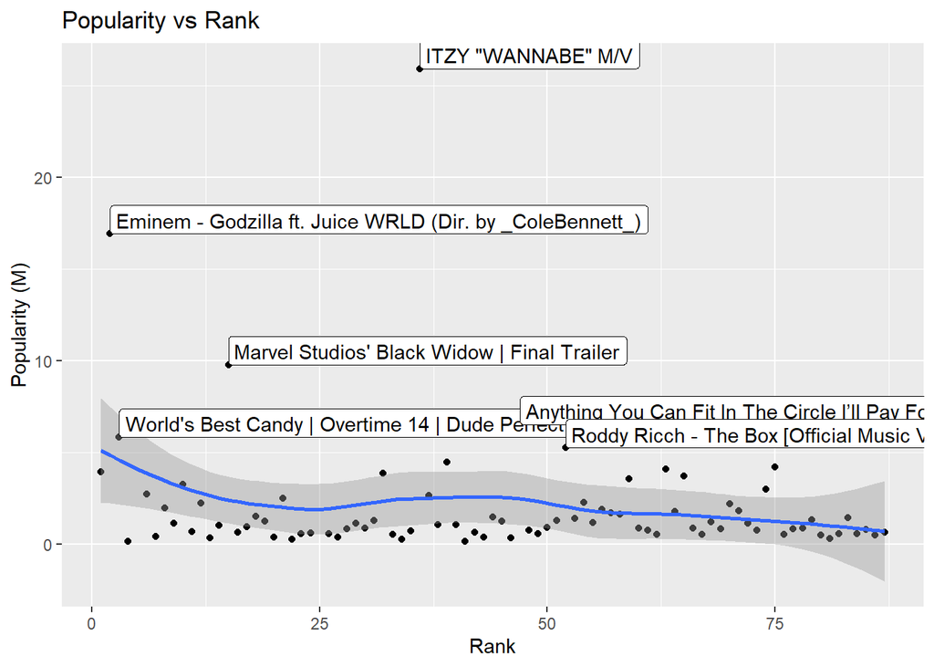

```r
ggplot(youtube.clean, aes(rank, popularity/1000000, label=title)) +
  geom_point() +
  geom_smooth() +
  geom_label(aes(label=ifelse(popularity/1000000>5,as.character(title),NA)),hjust=0, vjust=0) +
  ggtitle("Popularity vs Rank") +
  xlab("Rank") +
  ylab("Popularity (M)")
```